# Modeling your research data: A crash course using R

ses

9/14/2021

# 1 Data wrangling

## 1.1 Exercise

Which three airlines do show the greatest average delay in the first quarter?

(Use the tidyverse approach.)

You’ll find the data set (including description) [here](https://vincentarelbundock.github.io/Rdatasets/doc/nycflights13/flights.html).

## 1.2 Solution

### 1.2.1 In pseudo code

take data “flights” THEN filter month jan to march THEN select delay THEN group by airline (carrier) THEN summarise mean delay arrange mean delay from biggest to smallest THEN filter delay the three largest mean delays

### 1.2.2 In R code

Some preparation:

```r
# make sure to install the packages (one time only!)
library(nycflights13)  # unless the package is on your machine
data(flights)
library(tidyverse)  # including ggplot, dplyr, ....
```

And now the R code:

```r
flights %>% # "and then do command, called the pipe, Contrl-Shift-M"
  filter(month <= 3) %>%
  select(month, dep_delay, carrier) %>%
  drop_na() %>%  # drop all rows with missing data, for simplicity
  group_by(carrier) %>%
  summarise(dep_delay_avg = mean(dep_delay))  %>%   # y = f(x)
  arrange(-dep_delay_avg) %>%
  mutate(position = 1:16) %>%
  filter(position <= 3)
```

```
## # A tibble: 3 × 3
##   carrier dep_delay_avg position
##   <chr>           <dbl>    <int>
## 1 OO               67          1
## 2 HA               24.5        2
## 3 EV               24.1        3
```

# 2 Data viz

## 2.1 Research question 1

Is there a correlation between delay and flight distance?

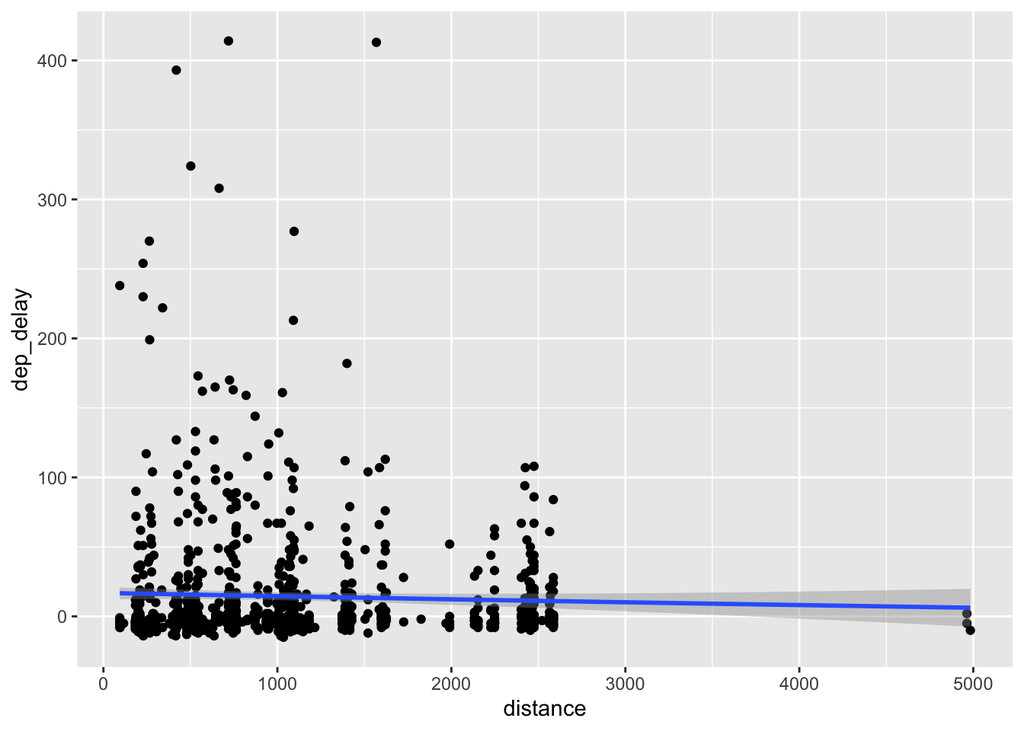

```r
flights %>%
  select(dep_delay, distance) %>%
  sample_n(size = 1000) %>%  # for speed
  ggplot() +
  aes(x = distance, y = dep_delay) +
  geom_point() +
  geom_smooth()
```

## 2.2 Research question 2

Is there a correlation between delay and flight distance? What is if we split the analysis (correlation) for each airport? (sub group analysis)

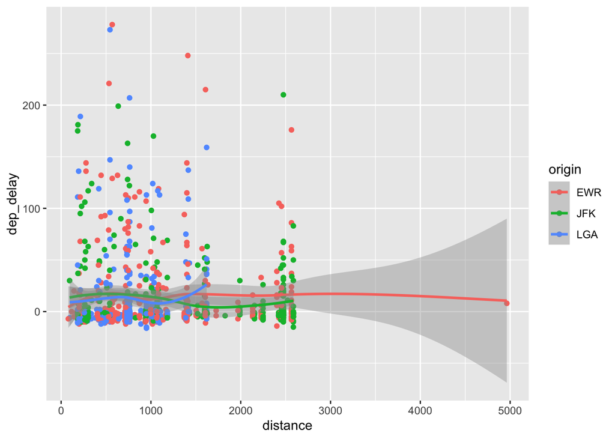

```r
flights %>%
  select(dep_delay, distance, origin) %>%
  sample_n(size = 1000) %>%  # for speed
  ggplot() +
  aes(x = distance, y = dep_delay, color = origin) +
  geom_point()+
  geom_smooth()
```

## 2.3 RQ 3

What is the distribution for delay in each month for each airport? Be sure to add a measure of centrality (e.g. median) and for spead (e.g., sd or IQR).

Tipp 1: Boxplots are depicted using the command `geom_boxplot()`! Tipp 2: Scribble before you code.

*11.40am back here*

```r
flights %>%
  select(dep_delay) %>%
  drop_na() %>%
  summarise(mean(dep_delay),
            sd(dep_delay))
```

```
## # A tibble: 1 × 2
##   `mean(dep_delay)` `sd(dep_delay)`
##               <dbl>           <dbl>
## 1              12.6            40.2
```

A rough rule of thumb is:

outlier is greater than mean + 2*sd.

```r
uprlimit <- 12.6 + 2*40.2
uprlimit
```

```
## [1] 93
```

that’s ifelse:

ifelse(test, if_yes_do, if_no_do)

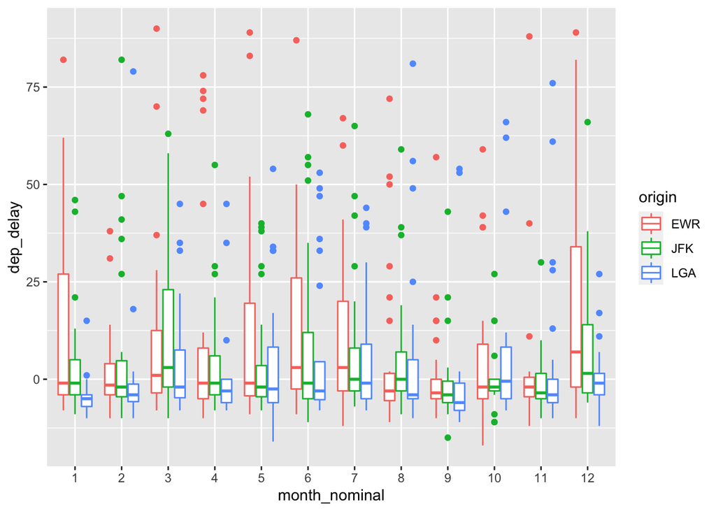

```r
flights %>%
  sample_n(1000) %>%
  mutate(is_outlier = ifelse(dep_delay > 93, 1, 0)) %>%
  filter(is_outlier == 0) %>%
  select(dep_delay, month, origin) %>%
  mutate(month_nominal = factor(month)) %>%
  ggplot() +
  aes(x = month_nominal, y = dep_delay, color = origin) +
  geom_boxplot()
```

# 3 Modelling

## 3.1 Simple regression

```r
library(moderndive)
data(evals)
```

```r
library(tidyverse)
library(moderndive)
library(skimr)
library(gapminder)
```

## 3.2 Preparation

```r
evals_ch5 <- evals %>%
  select(ID, score, bty_avg, age)
```

## 3.3 RQ

Is the teaching evaluation *depending* on the beauty of the teacher?

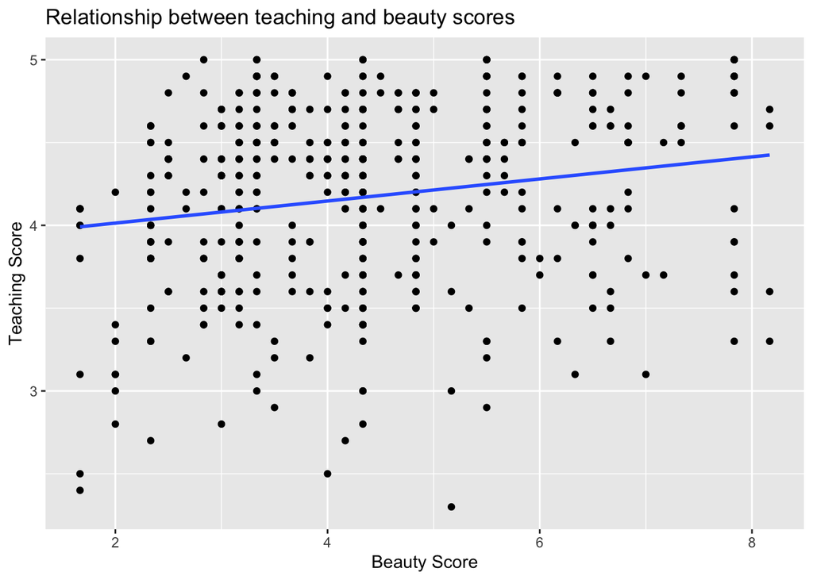

```r
evals_ch5 %>%
  ggplot(aes(x = bty_avg, y = score)) +
  geom_point() +
  labs(x = "Beauty Score", y = "Teaching Score",
       title = "Relationship between teaching and beauty scores") +
  geom_smooth(method = "lm", se = FALSE)
```

### 3.3.1 Pseudo code

```r
linear_model(output_var ~ input_var,
             data = my_spreadsheet)
```

### 3.3.2 Actual code

```r
model1 <- lm(score ~ bty_avg,  # y = f(x)
   data = evals_ch5)

model1
```

```
##
## Call:
## lm(formula = score ~ bty_avg, data = evals_ch5)
##
## Coefficients:
## (Intercept)      bty_avg
##     3.88034      0.06664
```

```r
get_regression_summaries(model1)
```

```
## # A tibble: 1 × 9
##   r_squared adj_r_squared   mse  rmse sigma statistic p_value    df  nobs
##       <dbl>         <dbl> <dbl> <dbl> <dbl>     <dbl>   <dbl> <dbl> <dbl>
## 1     0.035         0.033 0.285 0.534 0.535      16.7       0     1   463
```

## 3.4 Exercise Regression 1: numeric predictor

```r
library(moderndive)
data("evals")
```

### 3.4.1 Exercise

From [Chapter 5.1.2 ModernDive](https://moderndive.com/5-regression.html#model1table):

**(LC5.2)** Fit a new simple linear regression using `lm(score ~ age, data = evals_ch5)` where age is the new explanatory variable $x$. Get information about the “best-fitting” line from the regression table by applying the `get_regression_table()` function. How do the regression results match up with the results from your earlier exploratory data analysis?

### 3.4.2 Solution

```r
model2 <- lm(score ~ age, data = evals_ch5)
get_regression_table(model2)
```

```
## # A tibble: 2 × 7
##   term      estimate std_error statistic p_value lower_ci upper_ci
##   <chr>        <dbl>     <dbl>     <dbl>   <dbl>    <dbl>    <dbl>
## 1 intercept    4.46      0.127     35.2    0        4.21     4.71
## 2 age         -0.006     0.003     -2.31   0.021   -0.011   -0.001
```

```r
model2_preds <- get_regression_points(model2)
```

## 3.5 Exercise Regression 2: Binary predictor

Model `score` (DV/output) as explained by `gender` (IV/input); also visualize the model. Add an explorative data analysis (summary statistics plus visualization). Interpret your results. Note that `gender` is a binary (factor) variable. Using the data `evals` is probably the easiest way to get started (instead of `evals_ch5`).

*approx. 10 Min.*

```r
m3 <- lm(score ~ gender, data = evals)
m3
```

```
##
## Call:
## lm(formula = score ~ gender, data = evals)
##
## Coefficients:
## (Intercept)   gendermale
##      4.0928       0.1415
```

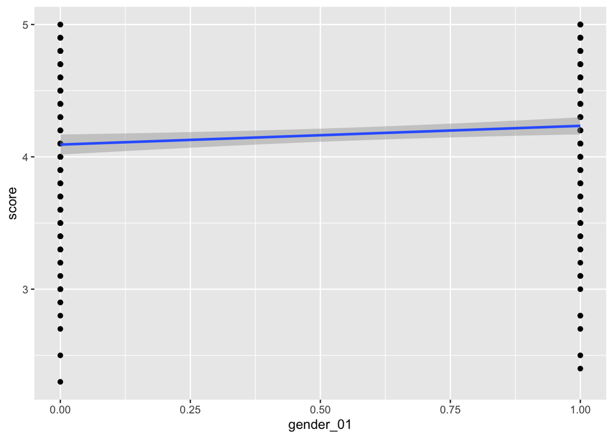

```r
evals %>%
  mutate(gender_01 = ifelse(gender == "female", 0, 1)) %>%
  ggplot() +
  aes(x = gender_01, y = score) +
  geom_point() +
  geom_smooth(method = "lm")
```

```r
evals %>%
  group_by(gender) %>%
  summarise(mean_per_group = mean(score))
```

```
## # A tibble: 2 × 2
##   gender mean_per_group
##   <fct>           <dbl>
## 1 female           4.09
## 2 male             4.23
```

## 3.6 Ex. Regression 3: multinomial predictor

Referring to [ModernDive, 5.2](https://moderndive.com/5-regression.html#model2EDA).

### 3.6.1 Ex

```r
lm(score ~ rank, data = evals)
```

```
##
## Call:
## lm(formula = score ~ rank, data = evals)
##
## Coefficients:
##      (Intercept)  ranktenure track       ranktenured
##           4.2843           -0.1297           -0.1452
```

Model the evaluation score as a function of `rank` of the teacher. Use `evals` as the data. Note that `rank` has 3 nominal values. Then, compute the mean values for each of the 3 groups.

# 4 Interaction

## 4.1 Preparing for interaction

### 4.1.1 Ex.

Model `score` by two input variables: `age` and `gender`. But as first step, just *visualize.* Be sure to take the right data frame :-)

Hint: Map `gender` to color :-)

### 4.1.2 Solution

Pseudo code:

```r
take the right table THEN
initialize ggplot THEN
define the 3 aesthetic mappings THEN
draw geom point THEN
draw geom smooth (of method "lm")
```

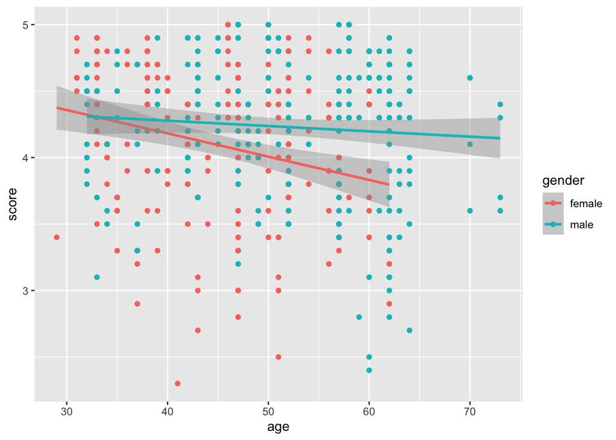

```r
ggplot(evals) +
  aes(y = score, x = age, color = gender) +
  geom_point() +
  geom_smooth(method = "lm")
```

This is an *interaction* model.

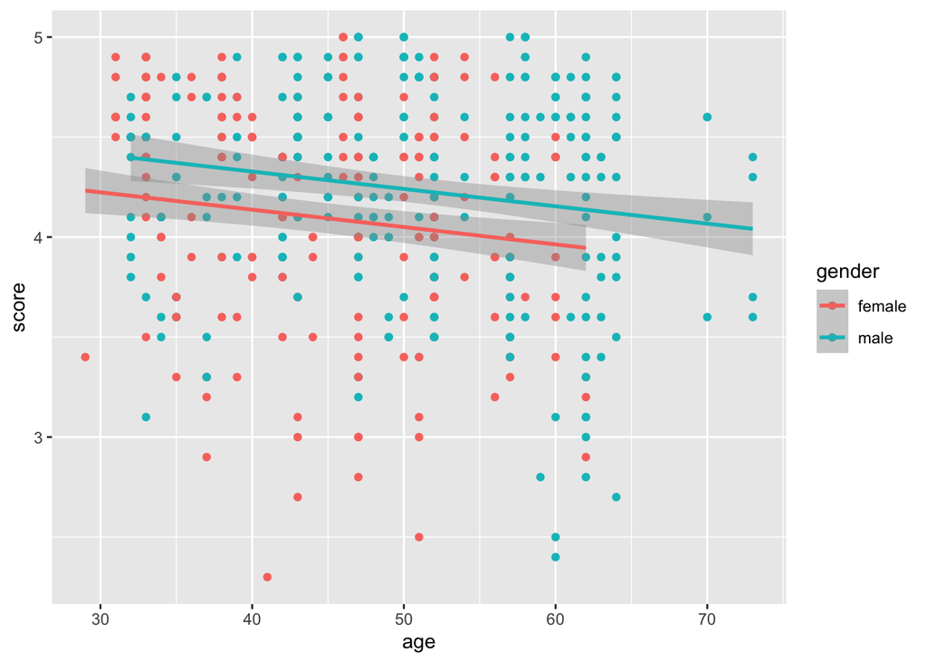

```r
ggplot(evals) +
  aes(y = score, x = age, color = gender) +
  geom_point() +
  geom_parallel_slopes()
```

This is a non-interaction model (“main effects” only).

## 4.2 Interaction model in R

```r
m4 <- lm(score ~ age + gender + age:gender,
         data = evals)
m4
```

```
##
## Call:
## lm(formula = score ~ age + gender + age:gender, data = evals)
##
## Coefficients:
##    (Intercept)             age      gendermale  age:gendermale
##        4.88299        -0.01752        -0.44604         0.01353
```

We can let R predict values:

Say, we want to know the score of a male teacher of age 70.

```r
predict(m4, newdata = data.frame(age = 70,
                                 gender = "male"))
```

```
##        1
## 4.157453
```

## 4.3 (Only) Main effects models

That’s the parralel slopes model.

```r
m5 <- lm(score ~ age + gender,
         data = evals)
m5
```

```
##
## Call:
## lm(formula = score ~ age + gender, data = evals)
##
## Coefficients:
## (Intercept)          age   gendermale
##    4.484116    -0.008678     0.190571
```

## 4.4 Ex. Interaction model 2

### 4.4.1 Ex.

Model `score` by beauty and gender and their joint interaction effect. Visualize the model. Interpret the results.

*approx. 10 max. 15 minutes.*

### 4.4.2 Solution

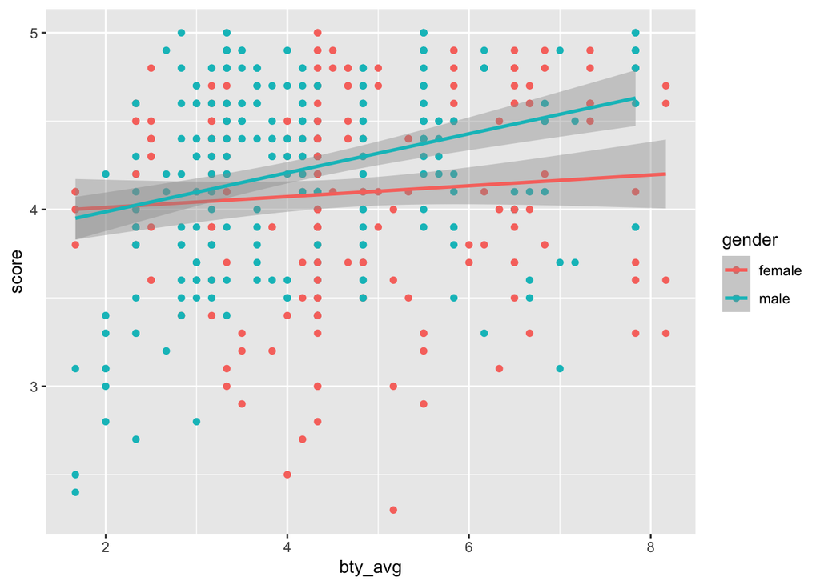

```r
evals %>%
  ggplot(aes(x = bty_avg, y = score, color = gender)) +
  geom_point() +
  geom_smooth(method = "lm")
```

```r
m6 <- lm(score ~ bty_avg + gender + bty_avg:gender,
         data = evals)
m6
```

```
##
## Call:
## lm(formula = score ~ bty_avg + gender + bty_avg:gender, data = evals)
##
## Coefficients:
##        (Intercept)             bty_avg          gendermale  bty_avg:gendermale
##            3.95006             0.03064            -0.18351             0.07962
```

## 4.5 Interaction model in R – recasted as “centered”

Centering is a useful activity for any model (at least numeric input variables).

```r
evals %>%
  summarise(mean(age))
```

```
## # A tibble: 1 × 1
##   `mean(age)`
##         <dbl>
## 1        48.4
```

```r
evals <-
evals %>%
  mutate(age_c = age - mean(age)) %>%
  relocate(age_c, .after = age)
```

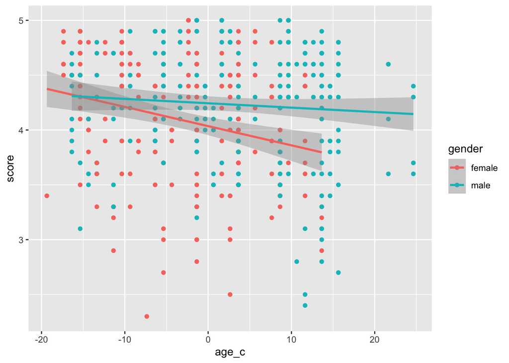

```r
ggplot(evals) +
  aes(y = score, x = age_c, color = gender) +
  geom_point() +
  geom_smooth(method = "lm")
```

```r
m4_c <- lm(score ~ age_c + gender + age_c:gender,
         data = evals)
m4_c
```

```
##
## Call:
## lm(formula = score ~ age_c + gender + age_c:gender, data = evals)
##
## Coefficients:
##      (Intercept)             age_c        gendermale  age_c:gendermale
##          4.03547          -0.01752           0.20836           0.01353
```

# 5 Model comparison

Which model should I prefer?

Listen to adjusted R squared!

Model with interaction:

```r
get_regression_summaries(m4)
```

```
## # A tibble: 1 × 9
##   r_squared adj_r_squared   mse  rmse sigma statistic p_value    df  nobs
##       <dbl>         <dbl> <dbl> <dbl> <dbl>     <dbl>   <dbl> <dbl> <dbl>
## 1     0.051         0.045 0.280 0.529 0.531      8.29       0     3   463
```

Model without interaction:

```r
get_regression_summaries(m3)
```

```
## # A tibble: 1 × 9
##   r_squared adj_r_squared   mse  rmse sigma statistic p_value    df  nobs
##       <dbl>         <dbl> <dbl> <dbl> <dbl>     <dbl>   <dbl> <dbl> <dbl>
## 1     0.017         0.014 0.290 0.539  0.54      7.75   0.006     1   463
```

So this comparison tells us to prefer Model 4 (model with interaction effect).